# 数学建模

### 模型知识点

### 变化模型-微分方程-捕食者模型

**Wang Haihua**

🚅 🚋😜 🚑 🚔

# Volterra 模型

一战期间，人们捕获的鲨鱼比例大幅上升，可以按照尝试，由于战争，人们停止捕捞，应该普通的鱼类和鲨鱼数量都会上升，为什么单单鲨鱼数量上升如此明显呢？ 为了解释这一问题，生物学家D. Ancona 向数学家Volterra求助，Volterra借用微分方程理论，成功地解释这个现象。

食饵（食用鱼）和捕食者（鲨鱼）在时刻$t$的数量分别记为$x(t),y(t)$，方便起见，你也可以用“大鱼吃小鱼”的比喻来理解这个模型。

[figure not shown]

因为大海中资源丰富，假设当食饵独立生存时以指数规律增长，增长率为$r$,于是

$$ \dfrac{\mathrm{d}x}{\mathrm{d}t} = rx $$

但是捕食者的存在，使得食饵的增长率减小，设减少率与捕食者的数量成正比，于是$x(t)$满足方程

$$ \dfrac{\mathrm{d}x}{\mathrm{d}t} = x(r-ay) = rx - axy \tag{1} $$

比例系数$a$反映捕食者捕食食饵的能力。

捕食者离开食饵无法生存，设它独自存在时死亡率为$d$,即

$$ \dfrac{\mathrm{d}y}{\mathrm{d}t} = -dy $$

而食饵的存在为捕食者提供了食物，相当于使捕食者的死亡率降低，且促使其增长。设增长率与食饵数量成正比，于是$y(t)$满足

$$ \dfrac{\mathrm{d}y}{\mathrm{d}t} = y (-d + bx) = -dy + bxy \tag{2} $$

比例系数$b$反映食饵对捕食者的供养能力。

将以上推导的结果写在一起，得到

$$ \begin{cases} \dfrac{\mathrm{d}x}{\mathrm{d}t} = x(r-ay) = rx - axy \\ \dfrac{\mathrm{d}y}{\mathrm{d}t} = y (-d + bx) = -dy + bxy \end{cases} $$

这就是自然环境中食饵和捕食者之间的依存和制约的关系。这里没有考虑种群自身的阻滞增长作用，是Volterra提出的最简单的模型。

数值递推公式为

$$ \begin{cases} x(t+\Delta t) = x(t) + \Delta t\left[rx(t) - ax(t)y(t)\right]\\ y(t+\Delta t) = y(t) + \Delta t\left[-dy(t) + bx(t)y(t)\right]\\ \end{cases} $$

```python
import matplotlib.pyplot as plt
%matplotlib inline
## Volterra 模型的数值求解示例

# 输入初始参数
r = 1
d = 0.5
a = 0.1
b = 0.02
x0 = 5
y0 = 12
deltaT = 0.01
TotTime = 30
timeStep = TotTime/deltaT
xlist = []
ylist = []
xlist.append(x0)
ylist.append(y0)
TimeList = [i*deltaT for i in range(int(timeStep))]
```

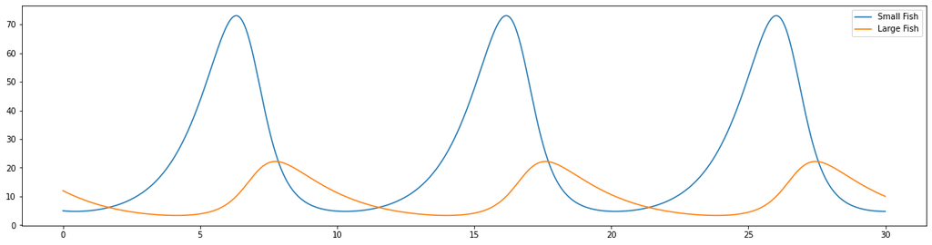

```python
# 递推地求解差分方程
for time in TimeList:
    xlist.append(xlist[-1] +deltaT * (r *xlist[-1] - a*xlist[-1]*ylist[-1] ) )
    ylist.append(ylist[-1] +deltaT * (-d *ylist[-1] + b*xlist[-1]*ylist[-1] ) )
# 变化过程可视化
plt.figure(figsize = (20,5))
plt.plot(TimeList,xlist[:-1],label = 'Small Fish')
plt.plot(TimeList,ylist[:-1],label = 'Large Fish')
plt.legend()
```

可以猜测，$x(t),y(t)$是周期函数，与此相应地，相轨线$y(x)$是封闭曲线。

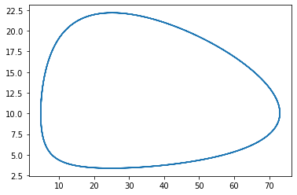

```python
# 绘制相轨线
plt.plot(xlist,ylist)
```

在数值解中我们看到，$x(t),y(t)$一个周期的平均值为$\overline x=25,\overline y = 10$, 这个数值与稳定平衡点刚好相等。

$$ \overline x = x_0 = \frac{d}{b}, \quad \overline y = y_0 = \frac{r}{a} $$

当然这也是能够通过解析方法来证明的

$$ x(t)=\frac{1}{b}\left(\frac{\dot{y}}{y}+d\right) $$$$ \bar{x}=\frac{1}{T} \int_{0}^{T} x(t) \mathrm{d} t=\frac{1}{T}\left[\frac{\ln y(T)-\ln y(0)}{b}+\frac{d T}{b}\right]=\frac{d}{b} $$

类似的，我们有

$$ \bar{y}=\frac{r}{a} $$

注意到，$r,d,a,b$在生态学上的意义，上述结果表明，

- 捕食者的数量(用一个周期内的平均值$\overline y$代替)与食饵增长率$r$成正比，与他掠食食饵的能力$a$成反比；
- 食饵的数量（用一个周期内的平均值$\overline x$代替）与捕食者死亡率$d$成正比，与他供养捕食者的能力$b$成反比。

Volterra用这个模型来解释生物学家D'Ancona提出的问题：

我们在上面的模型中引入人为捕捞的影响，引入捕捞量系数$e$，相当于食饵增长率由$r$下降为$r-e$，而捕食者死亡率由$d$上升为$d+e$,用$\overline {x_1},\overline {y_1}$表示这种情况下食用鱼（食饵）和鲨鱼（捕食者）的平均数量，则套用上面的公式可知

$$ \overline {x_1} = \dfrac{d+e}{b} \quad \overline {y_1} = \dfrac{r-e}{a} $$

显然，$\overline {x_1} > x_1, {y_1} < \overline {y_1}$

战争期间捕获量下降，即捕获系数变为$e'<e$，于是食用鱼和鲨鱼的数量变为

$$ \overline {x_1} = \dfrac{d+e'}{b} \quad \overline {y_1} = \dfrac{r-e'}{a} $$

显然，$\overline {x_2} < \overline {x_1}, \overline {y_2} > \overline {y_1}$，这正说明战争期间鲨鱼的比例会有明显的增加。

# 加入logistic项的Volterra模型

尽管Volterra模型可以解释一些现象，但是它作为近似反映现实对象的一个数学模型，必然存在不少局限性． 比如，许多生态学家指出，多数食饵－捕食者系统都观察不到Volterra模型 显示的那种周期震荡，而是趋向某种平衡状态，即系统存在稳定平衡点．实际上， 只要在Volterra模型中加入考虑自身阻滞作用的logistic项，就可以模拟这一现象。

$$ \begin{aligned} &\dot{x}_{1}(t)=r_{1} x_{1}\left(1-\frac{x_{1}}{N_{1}}-\sigma_{1} \frac{x_{2}}{N_{2}}\right)\\ &\dot{x}_{2}(t)=r_{2} x_{2}\left(-1+\sigma_{2} \frac{x_{1}}{N_{1}}-\frac{x_{2}}{N_{2}}\right) \end{aligned} $$

```python
## 加入logistic项的Volterra模型

# 输入初始参数
r1 = 0.2
r2 = 0.1
N1 = 50
N2 = 60
sigma1 = 1.2
sigma2 = 2.5
x0 = 25
y0 = 2
deltaT = 0.01
TotTime = 50
timeStep = TotTime/deltaT
xlist = []
ylist = []
xlist.append(x0)
ylist.append(y0)
TimeList = [i*deltaT for i in range(int(timeStep))]
```

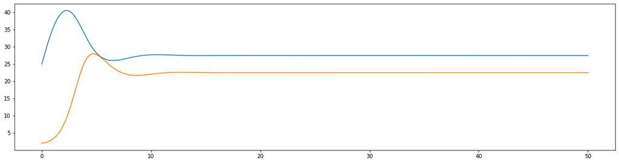

```python
# 递推地求解差分方程
for time in TimeList:
    xlist.append(xlist[-1] +deltaT * (r *xlist[-1])*(1 - xlist[-1]/N1 - sigma1 * ylist[-1]/N2))
    ylist.append(ylist[-1] +deltaT * (r *ylist[-1])*(-1 +sigma2* xlist[-1]/N1 -  ylist[-1]/N2))

# 结果可视化
plt.figure(figsize = (20,5))
plt.plot(TimeList,xlist[:-1])
plt.plot(TimeList,ylist[:-1])
```

**参考文献**

- ThomsonRen 的 github https://github.com/ThomsonRen/mathmodels